# Analysis of grid robust optimization heuristic

The files I’m analyzing here were run on three servers: Gaya, Apollo and Beatrix. They analyze the six instances (IEEE24, 30, 39, 57, 118, 300), each time varying different heuristic or problem parameters.

- Budget $\in\{5, 15, 50, 100, 200\}$
- upgrade_selection_bias $\in\{25\%, 50\%\}$ – this parameter controls the weight given to the failure of upgrading existing grids (with weights relative to failure in scenarios), versus a completely random selection of new edges or existing edges candidate for capacity upgrades
- min_neighbors $\in\{10, 25, 50\}$ – this parameter controls the number of iterations in a neighborhood (#neighbors) which will be examined before moving to a different neighborhood. The logic works in the following manner: if no (new) incumbent solution has been reached during the last MIN_NEIGHBORS iterations (of the current neighborhood), jump to a new neighborhood by resetting to the initial solution.

The files have been feched from the server and are stored in this git repository in the same location as this file.

```
Observations: 166,250
Variables: 18
$ time_stamp_str                 <chr> "2018-06-21-12-19-05", "2018-06-21-12-19-09", "2018-06-21-12-19-11", "2018-06-21-1...
$ current_time                   <dbl> 1529583546, 1529583550, 1529583552, 1529583554, 1529583556, 1529583558, 1529583560...
$ args.instance_location         <chr> "instance24", "instance24", "instance24", "instance24", "instance24", "instance24"...
$ budget                         <dbl> 5, 5, 5, 5, 5, 5, 5, 5, 5, 5, 5, 5, 5, 5, 5, 5, 5, 5, 5, 5, 5, 5, 5, 5, 5, 5, 5, 5...
$ full_destruct_probability      <dbl> 0.1, 0.1, 0.1, 0.1, 0.1, 0.1, 0.1, 0.1, 0.1, 0.1, 0.1, 0.1, 0.1, 0.1, 0.1, 0.1, 0....
$ upgrade_selection_bias         <dbl> 0.25, 0.25, 0.25, 0.25, 0.25, 0.25, 0.25, 0.25, 0.25, 0.25, 0.25, 0.25, 0.25, 0.25...
$ left_budget                    <dbl> 5, 5, 5, 5, 5, 5, 5, 5, 5, 5, 5, 5, 5, 5, 5, 5, 5, 5, 5, 5, 5, 5, 5, 5, 5, 5, 5, 5...
$ loop_counter                   <int> 0, 1, 2, 3, 4, 5, 6, 7, 8, 9, 10, 11, 12, 13, 14, 15, 16, 17, 18, 19, 20, 21, 22, ...
$ num_improvements               <int> 1, 1, 1, 1, 1, 1, 1, 1, 1, 1, 1, 1, 1, 1, 1, 1, 1, 1, 1, 1, 1, 1, 1, 1, 1, 1, 1, 1...
$ current_supply                 <dbl> 2588.4, 2588.4, 2588.4, 2588.4, 2588.4, 2588.4, 2588.4, 2588.4, 2588.4, 2588.4, 25...
$ total_demand                   <dbl> 2850, 2850, 2850, 2850, 2850, 2850, 2850, 2850, 2850, 2850, 2850, 2850, 2850, 2850...
$ neighborhoods_searched         <int> 0, 0, 0, 0, 0, 0, 0, 0, 0, 0, 0, 1, 1, 1, 1, 1, 1, 1, 1, 1, 1, 2, 2, 2, 2, 2, 2, 2...
$ min_neighbors_per_neighborhood <dbl> 10, 10, 10, 10, 10, 10, 10, 10, 10, 10, 10, 10, 10, 10, 10, 10, 10, 10, 10, 10, 10...
$ current_incumbent              <chr> "True", "False", "False", "False", "False", "False", "False", "False", "False", "F...
$ min_neighborhoods              <int> 50, 50, 50, 50, 50, 50, 50, 50, 50, 50, 50, 50, 50, 50, 50, 50, 50, 50, 50, 50, 50...
$ local_improvement_ratio        <dbl> 0.05, 0.05, 0.05, 0.05, 0.05, 0.05, 0.05, 0.05, 0.05, 0.05, 0.05, 0.05, 0.05, 0.05...
$ overall_improvement_ratio      <dbl> 0.01, 0.01, 0.01, 0.01, 0.01, 0.01, 0.01, 0.01, 0.01, 0.01, 0.01, 0.01, 0.01, 0.01...
$ temporary_grid_outcome         <dbl> 2588.4, 2588.4, 2588.4, 2588.4, 2588.4, 2588.4, 2588.4, 2588.4, 2588.4, 2588.4, 25...
```

The measures (output) from the heuristic include:

- time_stamp_str a timestamp of the line. Note that this was run in parallel in three servers so the timeline is mixed.
- current_time same as time_stamp_str only in seconds since epoch
- args.intance_location – which instance this is (which grid)
- budget – the budget constraint
- full_destruct_probability – currently held constant at $10\%$, this parameter controlls the proportion of cases in which edges are completely destrcuted, during the `downgrade` operation
- upgrade_selection_bias – one of the paramters we varied, see previous paragraph for explanations.
- left_budget – during the heuristic run, a global variable, `left_budget`, is continuosly varied around $0$. Where $\geq0$ is the cutpoint for a feasible solution.
- loop_counter – the total number of iterations so far
- num_improvements – number of iterations which found an incumbent (minimum 1)
- current_supply – the objective value for the current line
- total_demand – grid demand (same demand per instance)
- neighborhoods_searched – how many neighborhoods have been searched so far
- min_neighbors_per_neighborhood – see parameter `min_neighbors` which was explained in the previous paragraph
- current_incumbent – is this an incumbent solution?
- min_neighborhoods – the minimum number of neighborhoods to be searched before stopping the heuristic (if no improvement was found)
- local_improvement_ratio – what is the improvement ratio in the current neighborhood
- overall_improvement_ratio – what is the improvement ratio of the heuristic, relative to the current run
- temporary_grid_outcome – the value of the temporary solution (not necessarily incumbent, as in `current_supply`)

# Setup Parameter Influence

First question: **What is the influence of each of the setup paramters we examined (`upgrade_selection_bias` and `min_neighbors`) on the convergence of the algorithm?**

## The influence of `upgrade_selection_bias`

The influence is not consistent, there seems to be an interaction with other parameters.

```r
plot.data.selection.bias <- hr_data %>%
  filter(current_incumbent == "True") %>%
  mutate(supply_percent = current_supply/total_demand) %>%
  group_by(upgrade_selection_bias, budget, args.instance_location, min_neighbors_per_neighborhood) %>%
  summarize(supply_percent = max(supply_percent)) %>%
  spread(key = upgrade_selection_bias, value = supply_percent) %>%
  mutate(selection.bias.diff = (`0.5`-`0.25`))
plot.data.selection.bias
```

| budget | args.instance_location | min_neighbors_per_neighborhood | 0.25 | 0.5 | selection.bias.diff |
| --- | --- | --- | --- | --- | --- |
| 5 | instance118 | 10 | 0.8232720 | 0.8267893 | 3.517209e-03 |
| 5 | instance118 | 25 | 0.8397454 | 0.8148939 | -2.485149e-02 |
| 5 | instance118 | 50 | 0.8345403 | 0.8313296 | -3.210750e-03 |
| 5 | instance24 | 10 | 0.9082105 | 0.9082105 | 0.000000e+00 |
| 5 | instance24 | 25 | 0.9082105 | 0.9082105 | 0.000000e+00 |
| 5 | instance24 | 50 | 0.9082105 | 0.9082105 | 0.000000e+00 |
| 5 | instance30 | 10 | 0.9798414 | 0.9773996 | -2.441860e-03 |
| 5 | instance30 | 25 | 0.9694820 | 0.9764799 | 6.997886e-03 |
| 5 | instance30 | 50 | 0.9764799 | 0.9773996 | 9.196617e-04 |
| 5 | instance300 | 10 | 0.8965703 | 0.8961796 | -3.907387e-04 |

[output cut: 80 more lines]

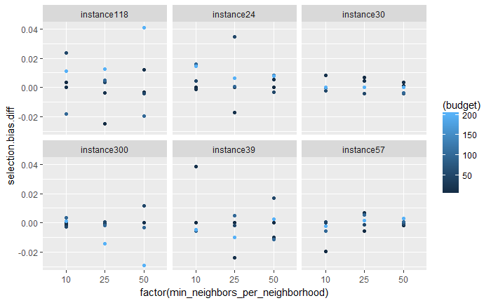

```r
ggplot(plot.data.selection.bias, aes(y = selection.bias.diff, x = factor(min_neighbors_per_neighborhood))) +
  geom_point(aes(color = (budget))) + facet_wrap(~args.instance_location)
```

```r
convergence.rate.selection.bias <- hr_data %>%
  filter(current_incumbent == "True") %>%
  mutate(supply_percent = current_supply/total_demand) %>%
  left_join(hr_data %>%
              group_by(budget, min_neighbors_per_neighborhood, args.instance_location, upgrade_selection_bias) %>%
              summarize(start.time = min(current_time))
              ) %>%
  mutate(current_time = current_time - start.time)
convergence.rate.selection.bias
```

| time_stamp_str | current_time | args.instance_location | budget | full_destruct_probability | upgrade_selection_bias | left_budget | loop_counter | num_improvements | current_supply | total_demand | neighborhoods_searched | min_neighbors_per_neighborhood | current_incumbent | min_neighborhoods | local_improvement_ratio | overall_improvement_ratio | temporary_grid_outcome | supply_percent | start.time |
| --- | --- | --- | --- | --- | --- | --- | --- | --- | --- | --- | --- | --- | --- | --- | --- | --- | --- | --- | --- |
| 2018-06-21-12-19-05 | 0.000 | instance24 | 5 | 0.1 | 0.25 | 5.000000e+00 | 0 | 1 | 2588.400 | 2850.00 | 0 | 10 | True | 50 | 0.05 | 0.01 | 2588.400 | 0.9082105 | 1529583546 |
| 2018-06-21-12-35-54 | 0.000 | instance24 | 15 | 0.1 | 0.25 | 3.315294e+00 | 0 | 1 | 2582.000 | 2850.00 | 0 | 10 | True | 50 | 0.05 | 0.01 | 2582.000 | 0.9059649 | 1529584554 |
| 2018-06-21-12-36-00 | 5.797 | instance24 | 15 | 0.1 | 0.25 | 3.315294e+00 | 2 | 2 | 2601.640 | 2850.00 | 0 | 10 | True | 50 | 0.05 | 0.01 | 2601.640 | 0.9128561 | 1529584554 |
| 2018-06-21-12-36-07 | 13.609 | instance24 | 15 | 0.1 | 0.25 | 3.315294e+00 | 6 | 3 | 2608.360 | 2850.00 | 0 | 10 | True | 50 | 0.05 | 0.01 | 2608.360 | 0.9152140 | 1529584554 |
| 2018-06-21-12-36-11 | 17.515 | instance24 | 15 | 0.1 | 0.25 | 2.315294e+00 | 8 | 4 | 2625.660 | 2850.00 | 0 | 10 | True | 50 | 0.05 | 0.01 | 2625.660 | 0.9212842 | 1529584554 |
| 2018-06-21-12-36-35 | 41.077 | instance24 | 15 | 0.1 | 0.25 | 4.315294e+00 | 20 | 5 | 2627.920 | 2850.00 | 1 | 10 | True | 50 | 0.05 | 0.01 | 2627.920 | 0.9220772 | 1529584554 |
| 2018-06-21-12-36-50 | 56.467 | instance24 | 15 | 0.1 | 0.25 | 5.315294e+00 | 28 | 6 | 2638.040 | 2850.00 | 1 | 10 | True | 50 | 0.05 | 0.01 | 2638.040 | 0.9256281 | 1529584554 |
| 2018-06-21-12-37-15 | 81.320 | instance24 | 15 | 0.1 | 0.25 | 6.305882e-01 | 41 | 7 | 2656.980 | 2850.00 | 2 | 10 | True | 50 | 0.05 | 0.01 | 2656.980 | 0.9322737 | 1529584554 |
| 2018-06-21-12-37-21 | 87.210 | instance24 | 15 | 0.1 | 0.25 | 6.305882e-01 | 44 | 8 | 2657.160 | 2850.00 | 2 | 10 | True | 50 | 0.05 | 0.01 | 2657.160 | 0.9323368 | 1529584554 |
| 2018-06-21-12-37-35 | 100.944 | instance24 | 15 | 0.1 | 0.25 | 2.630588e+00 | 51 | 9 | 2659.020 | 2850.00 | 2 | 10 | True | 50 | 0.05 | 0.01 | 2659.020 | 0.9329895 | 1529584554 |

[output cut: 990 more lines]

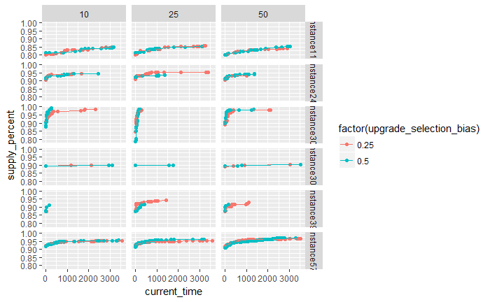

```r
ggplot(convergence.rate.selection.bias %>% filter(budget == 15),
       aes(x = current_time, y = supply_percent, color = factor(upgrade_selection_bias))) +
  geom_point() + geom_line() + facet_grid(args.instance_location ~ min_neighbors_per_neighborhood)
```

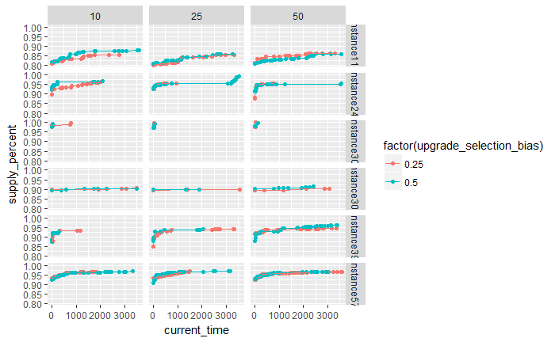

```r
ggplot(convergence.rate.selection.bias %>% filter(budget == 50),
       aes(x = current_time, y = supply_percent, color = factor(upgrade_selection_bias))) +
  geom_point() + geom_line() + facet_grid(args.instance_location ~ min_neighbors_per_neighborhood)
```

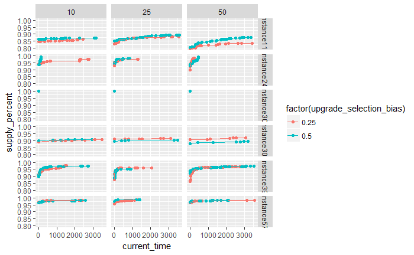

```r
ggplot(convergence.rate.selection.bias %>% filter(budget == 200),
       aes(x = current_time, y = supply_percent, color = factor(upgrade_selection_bias))) +
  geom_point() + geom_line() + facet_grid(args.instance_location ~ min_neighbors_per_neighborhood)
```

It is hard to discern any specific trend relating to the upgrade_selection_bias, it seems that the objective value is not sensitive to this, which seems to indicate that this is not the most important parameter, probably due to the fact that the upgrade_selection_bias only deals with capacity upgrades and ignores establishment of new edges - which are covered during the run and in cases of new neighborhoods.

Moving on to the new parameter, the `min_neighbors_per_neighborhood` and understanding how it influences the convergence or the solution.

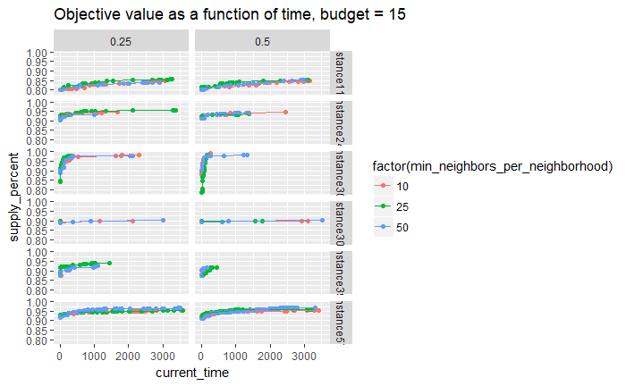

```r
plot.data.min.neighbors <- hr_data %>%
  filter(current_incumbent == "True") %>%
  mutate(supply_percent = current_supply/total_demand) %>%
  group_by(upgrade_selection_bias, budget, args.instance_location, min_neighbors_per_neighborhood) %>%
  summarize(supply_percent = max(supply_percent)) %>%
  spread(key = min_neighbors_per_neighborhood, value = supply_percent)
ggplot(convergence.rate.selection.bias %>% filter(budget == 15),
       aes(x = current_time, y = supply_percent, color = factor(min_neighbors_per_neighborhood))) +
  geom_point() + geom_line() + facet_grid(args.instance_location ~ upgrade_selection_bias) +
  ggtitle("Objective value as a function of time, budget = 15")
```

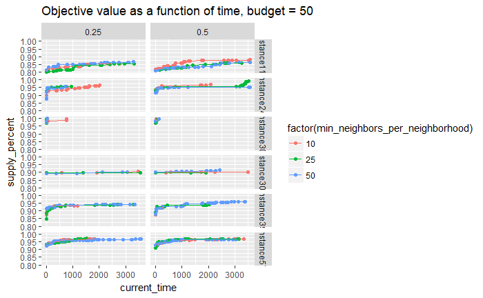

```r
ggplot(convergence.rate.selection.bias %>% filter(budget == 50),
       aes(x = current_time, y = supply_percent, color = factor(min_neighbors_per_neighborhood))) +
  geom_point() + geom_line() + facet_grid(args.instance_location ~ upgrade_selection_bias) +   ggtitle("Objective value as a function of time, budget = 50")
```

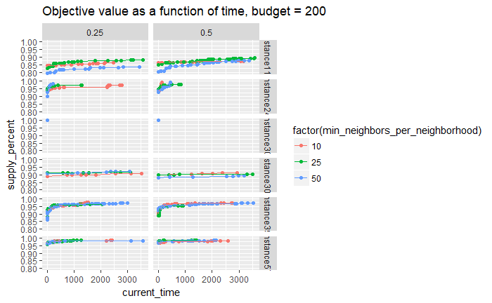

```r
ggplot(convergence.rate.selection.bias %>% filter(budget == 200),
       aes(x = current_time, y = supply_percent, color = factor(min_neighbors_per_neighborhood))) +
  geom_point() + geom_line() + facet_grid(args.instance_location ~ upgrade_selection_bias) +   ggtitle("Objective value as a function of time, budget = 200")
```

## Comparison of the objective value in the heuristic algorithm versus the objective value in the 1-depth optimization

The following code assumes that `results_one_depth_analysis.R` has been run. For these charts, I’m only using specific setup parameters, i.e.:

- `min_neighbors_per_neighborhood` $=25$
- `upgrade_selection_bias` $=50\%$

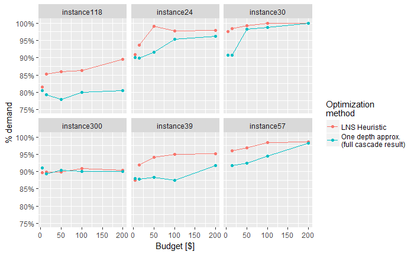